# Exploratory Data Work for the bank dataset

Feng Ruiwan <sub><Email:feng0107@e.ntu.edu.sg></sub>

Oct 2019

# Finding 1

```r
data <- bank %>%
  group_by(job) %>%
  summarise(primary = sum(ifelse(education == "primary", 1, 0)),
            secondary = sum(ifelse(education == "secondary", 1, 0)),
            tertiary = sum(ifelse(education == "tertiary", 1, 0))) %>%
  arrange(desc(tertiary))
knitr::kable(data)
```

| job | primary | secondary | tertiary |
| --- | --- | --- | --- |
| management | 39 | 116 | 787 |
| technician | 15 | 520 | 211 |
| self-employed | 15 | 76 | 88 |
| entrepreneur | 26 | 58 | 73 |
| admin. | 17 | 393 | 51 |
| unemployed | 26 | 68 | 32 |
| retired | 80 | 105 | 31 |
| housemaid | 57 | 28 | 22 |
| student | 2 | 47 | 19 |
| services | 25 | 363 | 16 |
| blue-collar | 369 | 524 | 12 |
| unknown | 7 | 8 | 8 |

**Most people with higher education backgroud are in management sector; Blue collars hardly have a tertiary background, and most with primary background are blue collars; Most administrators and technicians have primary or secondary education level.**

# Finding 2

```r
data <- (group_by(bank, education) %>%
           summarise(mean_balance = mean(balance),
                     house_mean = mean(ifelse(housing == "yes", 1, 0)),
                     default_mean = mean(ifelse(housing == "yes", 1, 0)), count = n()))
knitr::kable(data)
```

| education | mean_balance | house_mean | default_mean | count |
| --- | --- | --- | --- | --- |
| primary | 1411.544 | 0.5648968 | 0.5648968 | 678 |
| secondary | 1196.814 | 0.6201214 | 0.6201214 | 2306 |
| tertiary | 1775.424 | 0.4911111 | 0.4911111 | 1350 |
| unknown | 1701.246 | 0.4438503 | 0.4438503 | 187 |

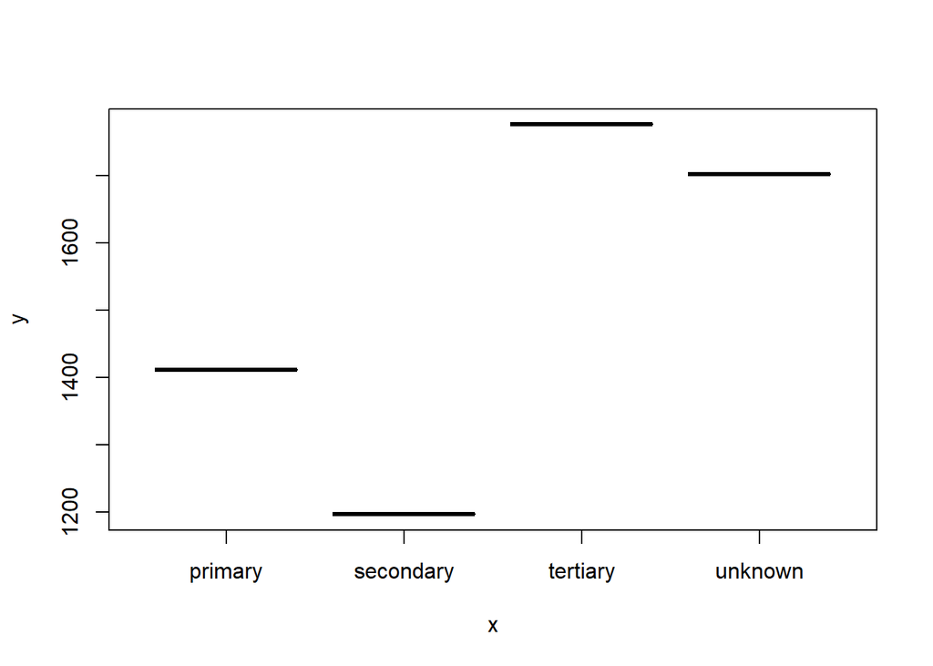

```r
plot(data$education, data$mean_balance)
```

# Finding 3

```r
df <- bank %>%
  group_by(job) %>%
  filter(min_rank(balance) == 1 | min_rank(desc(balance)) == 1) %>%
  arrange(job, balance)
knitr::kable(df)
```

| age | job | marital | education | default | balance | housing | loan | contact | day | month | duration | campaign | pdays | previous | poutcome | y |
| --- | --- | --- | --- | --- | --- | --- | --- | --- | --- | --- | --- | --- | --- | --- | --- | --- |
| 57 | admin. | married | secondary | no | -967 | yes | no | telephone | 15 | may | 8 | 7 | -1 | 0 | unknown | no |
| 29 | admin. | married | secondary | no | 22171 | yes | no | cellular | 18 | may | 44 | 1 | 355 | 3 | failure | no |
| 46 | blue-collar | married | secondary | no | -1400 | yes | no | telephone | 6 | may | 309 | 3 | 355 | 4 | failure | no |
| 67 | blue-collar | married | secondary | no | 16353 | no | no | cellular | 27 | oct | 223 | 2 | -1 | 0 | unknown | no |
| 51 | entrepreneur | married | secondary | yes | -2082 | no | yes | cellular | 28 | jul | 123 | 6 | -1 | 0 | unknown | no |
| 42 | entrepreneur | married | tertiary | no | 42045 | no | no | cellular | 8 | aug | 205 | 2 | -1 | 0 | unknown | no |
| 26 | housemaid | married | secondary | no | -759 | yes | no | cellular | 11 | jul | 191 | 1 | -1 | 0 | unknown | no |
| 31 | housemaid | single | primary | no | 26965 | no | no | cellular | 21 | apr | 654 | 2 | -1 | 0 | unknown | yes |
| 44 | management | married | secondary | no | -1746 | yes | no | unknown | 20 | jun | 218 | 1 | -1 | 0 | unknown | no |
| 36 | management | married | tertiary | no | 27359 | yes | no | unknown | 3 | jun | 71 | 2 | -1 | 0 | unknown | no |
| 56 | retired | married | secondary | no | -1206 | yes | no | cellular | 15 | jun | 382 | 2 | -1 | 0 | unknown | yes |
| 60 | retired | married | primary | no | 71188 | no | no | cellular | 6 | oct | 205 | 1 | -1 | 0 | unknown | no |
| 57 | self-employed | married | tertiary | yes | -3313 | yes | yes | unknown | 9 | may | 153 | 1 | -1 | 0 | unknown | no |
| 36 | self-employed | married | tertiary | no | 16430 | yes | no | unknown | 6 | jun | 197 | 3 | -1 | 0 | unknown | no |
| 27 | services | married | secondary | no | -1202 | yes | no | unknown | 4 | jun | 749 | 2 | -1 | 0 | unknown | no |
| 50 | services | married | secondary | no | 26394 | no | no | cellular | 25 | aug | 206 | 4 | -1 | 0 | unknown | no |
| 23 | student | married | tertiary | yes | -230 | yes | no | cellular | 18 | may | 259 | 2 | -1 | 0 | unknown | no |
| 28 | student | single | secondary | no | 11555 | no | no | cellular | 8 | apr | 125 | 2 | -1 | 0 | unknown | no |
| 49 | technician | married | secondary | yes | -1680 | yes | yes | unknown | 27 | jun | 92 | 4 | -1 | 0 | unknown | no |
| 43 | technician | single | tertiary | no | 27733 | yes | no | unknown | 3 | jun | 164 | 7 | -1 | 0 | unknown | no |
| 36 | unemployed | married | secondary | no | -872 | yes | yes | cellular | 20 | nov | 153 | 1 | 183 | 1 | failure | no |
| 36 | unemployed | single | tertiary | no | 9019 | yes | no | unknown | 11 | jun | 952 | 3 | -1 | 0 | unknown | no |
| 56 | unknown | married | unknown | no | 0 | no | no | unknown | 20 | jun | 471 | 2 | -1 | 0 | unknown | no |
| 38 | unknown | single | tertiary | no | 0 | no | no | cellular | 11 | sep | 260 | 3 | 95 | 3 | success | yes |
| 49 | unknown | married | secondary | no | 0 | no | no | cellular | 28 | aug | 173 | 2 | -1 | 0 | unknown | no |
| 60 | unknown | married | unknown | no | 7337 | no | no | cellular | 4 | aug | 122 | 1 | -1 | 0 | unknown | no |

**Retired people are likely to save money, enterpreneurs tend to have more balance, with students and blue-collars have less in money account.**

# Finding 4

```r
df <- bank %>%
  group_by(y) %>%
  summarise(mean_balance = mean(balance),
            mean_pdays = mean(pdays),
            mean_pre_contact = mean(previous),
            mean_in_contact = mean(campaign),
            mean_pre_success = mean(ifelse(poutcome == "success", 1, 0)),
            count = n())
knitr::kable(df)
```

| y | mean_balance | mean_pdays | mean_pre_contact | mean_in_contact | mean_pre_success | count |
| --- | --- | --- | --- | --- | --- | --- |
| no | 1403.212 | 36.00600 | 0.471250 | 2.862250 | 0.011500 | 4000 |
| yes | 1571.956 | 68.63916 | 1.090211 | 2.266795 | 0.159309 | 521 |

**Most of people refuse to subscribe. It is more likely to success when marketing towards clients with more money in accounts. The contact times before campaign positively influence the outcome, and the time interval(since last contact for previous campaign) seems matter the outcome, if the last contact passed longer, the clients are more likely to subscribe a deposit. And previous subscribers tend to be more willing to subscribe again.**

# Finding 5

```r
df <- bank %>%
  group_by(y) %>%
  summarise(shouse_loan = sum(ifelse(housing == "yes", 1, 0)),
            sloan = sum(ifelse(loan == "yes", 1, 0)),
            smarital = sum(ifelse(marital == "married", 1, 0)),
            sdefault = sum(ifelse(default == "yes", 1, 0)),
            count = n())
knitr::kable(df)
```

| y | shouse_loan | sloan | smarital | sdefault | count |
| --- | --- | --- | --- | --- | --- |
| no | 2339 | 648 | 2520 | 67 | 4000 |
| yes | 220 | 43 | 277 | 9 | 521 |

**Peole without loan and housing loan are more likely subscribe, only few people subscribed had default behavior before.**

# Finding 6

```r
df <- bank %>% filter(balance > mean(balance), y == "yes") %>%
  group_by(job, education) %>% summarise(n = n())
knitr::kable(df)
```

| job | education | n |
| --- | --- | --- |
| admin. | secondary | 14 |
| admin. | tertiary | 2 |
| admin. | unknown | 2 |
| blue-collar | primary | 5 |
| blue-collar | secondary | 14 |
| blue-collar | unknown | 2 |
| entrepreneur | secondary | 3 |
| entrepreneur | tertiary | 1 |
| housemaid | primary | 3 |
| housemaid | secondary | 1 |
| housemaid | tertiary | 1 |
| management | primary | 5 |
| management | secondary | 5 |
| management | tertiary | 37 |
| management | unknown | 4 |
| retired | primary | 3 |
| retired | secondary | 12 |
| retired | tertiary | 7 |
| self-employed | tertiary | 5 |
| self-employed | unknown | 1 |
| services | primary | 1 |
| services | secondary | 7 |
| services | tertiary | 1 |
| services | unknown | 1 |
| student | primary | 1 |
| student | secondary | 2 |
| student | tertiary | 3 |
| technician | primary | 2 |
| technician | secondary | 13 |
| technician | tertiary | 11 |
| unemployed | primary | 1 |
| unemployed | secondary | 2 |
| unemployed | tertiary | 1 |
| unknown | secondary | 1 |
| unknown | unknown | 1 |

# Finding 7

```r
df <- bank %>%
  group_by(marital) %>%
   summarise(m_balance = median(balance),
             m_age = median(age),
             house_loan = mean(ifelse(housing == "yes", 1, 0)),
            loan_ = mean(ifelse(loan == "yes", 1, 0)))

knitr::kable(df)
```

| marital | m_balance | m_age | house_loan | loan_ |
| --- | --- | --- | --- | --- |
| divorced | 367.5 | 45 | 0.5643939 | 0.1704545 |
| married | 452.0 | 42 | 0.5809796 | 0.1619592 |
| single | 462.0 | 32 | 0.5317726 | 0.1237458 |

**Married people are more likely to have house loan, higher propotion of divorced have personal loan. For the median level, devorced people have lower balance compared to others**

# Finding 8

```r
df <- bank %>%
  group_by(age) %>%
   summarise(yes = sum(ifelse(y == "yes", 1, 0)),
             no = sum(ifelse(y == "no", 1, 0)))
df1 <-  gather(df, subscribe, count, -age) %>% arrange(age, subscribe)
knitr::kable(df1)
```

| age | subscribe | count |
| --- | --- | --- |
| 19 | no | 2 |
| 19 | yes | 2 |
| 20 | no | 2 |
| 20 | yes | 1 |
| 21 | no | 6 |
| 21 | yes | 1 |
| 22 | no | 6 |
| 22 | yes | 3 |
| 23 | no | 18 |
| 23 | yes | 2 |
| 24 | no | 20 |
| 24 | yes | 4 |
| 25 | no | 34 |
| 25 | yes | 10 |
| 26 | no | 70 |
| 26 | yes | 7 |
| 27 | no | 80 |
| 27 | yes | 14 |
| 28 | no | 87 |
| 28 | yes | 16 |
| 29 | no | 83 |
| 29 | yes | 14 |
| 30 | no | 134 |
| 30 | yes | 16 |
| 31 | no | 183 |
| 31 | yes | 16 |
| 32 | no | 196 |
| 32 | yes | 28 |
| 33 | no | 168 |
| 33 | yes | 18 |

[output cut: 104 more lines]

**People aged from 20 to 60 are more likely to refuse to subscribe**

# Finding 9

```r
df <- mutate(bank, age_group = case_when(
  age < 25 ~ "youth",
  age < 50 ~ "mid-age",
  TRUE ~ "senior"
))
df1 <- df %>%
  group_by(age_group) %>%
  summarise(married_ratio = sum(ifelse(marital == "married", 1, 0))/n()) %>%
  arrange(married_ratio)
knitr::kable(df1)
```

| age_group | married_ratio |
| --- | --- |
| youth | 0.2089552 |
| mid-age | 0.5814361 |
| senior | 0.7694553 |

**Marital ratio is highest among senior group, lowest within the youth**

# Finding 10

```r
df <- mutate(bank, balance_status = case_when(
  balance < 0 ~ "poor",
  balance < 5000 ~ "just so so",
  balance < 20000 ~ "middle class",
  balance < 30000 ~ "rich",
  TRUE ~ "wow"
))
df1 <- df %>%
  group_by(balance_status) %>%
  summarise(subscribe_ratio = sum(ifelse(y == "yes", 1, 0))/n(),
            aver_contact = mean(duration),
            count = n()) %>%
  arrange(count)
knitr::kable(df1)
```

| balance_status | subscribe_ratio | aver_contact | count |
| --- | --- | --- | --- |
| wow | 0.0000000 | 205.0000 | 2 |
| rich | 0.0555556 | 160.6111 | 18 |
| middle class | 0.1141869 | 246.3875 | 289 |
| poor | 0.0846995 | 265.0956 | 366 |
| just so so | 0.1185647 | 265.6882 | 3846 |

**Most people own balance between 0-5000, and numbers of people with negative balance ranked the second place. People belong to the “middle class” and “just so so” group are more likely to subscribe**